# Exploratory Data Analysis Report

Report by dlookr package

2020-03-10

# 1 Introduction

The EDA Report provides exploratory data analysis information on objects that inherit data.frame and data.frame.

## 1.1 Information of Dataset

The dataset that generated the EDA Report is an **‘data.frame’** object. It consists of **147 observations** and **6 variables**.

## 1.2 Information of Variables

The variable information of the data set that generated the EDA Report is shown in the following table.:

Information of Variables

| variables | types | missing_count | missing_percent | unique_count | unique_rate |
| --- | --- | --- | --- | --- | --- |
| GENDER | factor | 0 | 0 | 2 | 0.0136054 |
| CANCER | factor | 0 | 0 | 4 | 0.0272109 |
| INSvsMALI | integer | 0 | 0 | 2 | 0.0136054 |
| MedHouInc | integer | 0 | 0 | 12 | 0.0816327 |
| AgeDiagnosed | integer | 0 | 0 | 50 | 0.3401361 |
| MortalityRate | numeric | 0 | 0 | 39 | 0.2653061 |

The target variable of the data is **‘NULL’**, and the data type of the variable is **NULL(You did not specify a target variable)**.

## 1.3 About EDA Report

EDA reports provide information and visualization results that support the EDA process. In particular, it provides a variety of information to understand the relationship between the target variable and the rest of the variables of interest.

# 2 Univariate Analysis

## 2.1 Descriptive Statistics

edaData  
6 Variables 147 Observations

GENDER

| n | missing | distinct |
| --- | --- | --- |
| 147 | 0 | 2 |

```
 Value      Female   Male
 Frequency      80     67
 Proportion  0.544  0.456
```

CANCER

| n | missing | distinct |
| --- | --- | --- |
| 147 | 0 | 4 |

```
 Value        Breast Pancreas Prostate  Stomach
 Frequency        55       43       30       19
 Proportion    0.374    0.293    0.204    0.129
```

INSvsMALI

| n | missing | distinct | Info | Mean | Gmd |
| --- | --- | --- | --- | --- | --- |
| 147 | 0 | 2 | 0.242 | 1.088 | 0.1623 |

```
 Value          1     2
 Frequency    134    13
 Proportion 0.912 0.088
```

MedHouInc

| n | missing | distinct | Info | Mean | Gmd | .05 | .10 | .25 | .50 | .75 | .90 | .95 |
| --- | --- | --- | --- | --- | --- | --- | --- | --- | --- | --- | --- | --- |
| 147 | 0 | 12 | 0.931 | 6844 | 1093 | 5421 | 5421 | 6147 | 6502 | 7880 | 7880 | 7880 |

lowest : 4452 4718 5093 5421 5643 , highest: 6147 6285 6502 7353 7880

```
 Value       4452  4718  5093  5421  5643  5803  6026  6147  6285  6502  7353  7880
 Frequency      3     2     1    10     5     2     5    26     7    15    13    58
 Proportion 0.020 0.014 0.007 0.068 0.034 0.014 0.034 0.177 0.048 0.102 0.088 0.395
```

AgeDiagnosed

| n | missing | distinct | Info | Mean | Gmd | .05 | .10 | .25 | .50 | .75 | .90 | .95 |
| --- | --- | --- | --- | --- | --- | --- | --- | --- | --- | --- | --- | --- |
| 147 | 0 | 50 | 0.999 | 67.31 | 16.35 | 44.0 | 47.6 | 58.5 | 69.0 | 78.5 | 85.4 | 87.7 |

lowest : 26 28 32 39 40 , highest: 86 87 88 91 92

MortalityRate

| n | missing | distinct | Info | Mean | Gmd | .05 | .10 | .25 | .50 | .75 | .90 | .95 |
| --- | --- | --- | --- | --- | --- | --- | --- | --- | --- | --- | --- | --- |
| 147 | 0 | 39 | 0.998 | 69.68 | 77.01 | 5.11 | 8.70 | 19.50 | 38.10 | 94.00 | 173.28 | 217.20 |

lowest : 0.4 0.6 0.7 1.6 2.0 , highest: 124.4 173.0 173.7 217.2 452.9

## 2.2 Normality Test of Numerical Variables

### 2.2.1 Statistics and Visualization of (Sample) Data

**[ INSvsMALI ]**

normality test : Shapiro-Wilk normality test

statistic : 0.3187, p-value : 2.98301E-23

skewness and kurtosis

| type | skewness | kurtosis |
| --- | --- | --- |
| original | 2.899087 | 9.404707 |
| log transformation | 2.899087 | 9.404707 |
| sqrt transformation | 2.899087 | 9.404707 |

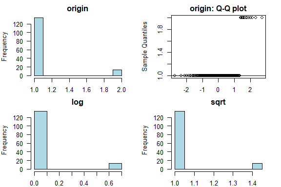

**[ MedHouInc ]**

normality test : Shapiro-Wilk normality test

```
 statistic : 0.84781,  p-value : 4.9148E-11
```

skewness and kurtosis

| type | skewness | kurtosis |
| --- | --- | --- |
| original | -0.3659887 | 1.966690 |
| log transformation | -0.6007933 | 2.564068 |
| sqrt transformation | -0.4741066 | 2.225996 |

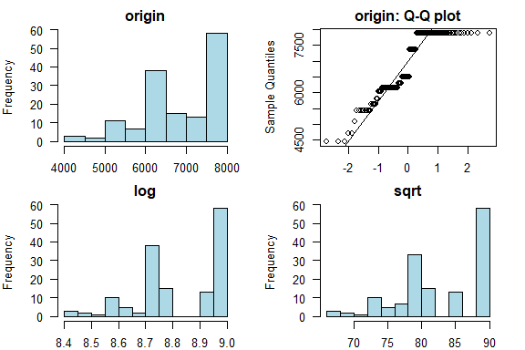

**[ AgeDiagnosed ]**

normality test : Shapiro-Wilk normality test

```
 statistic : 0.97278,  p-value : 0.0050672
```

skewness and kurtosis

| type | skewness | kurtosis |
| --- | --- | --- |
| original | -0.4700956 | 2.677354 |
| log transformation | -1.1279687 | 4.538864 |
| sqrt transformation | -0.7640928 | 3.346427 |

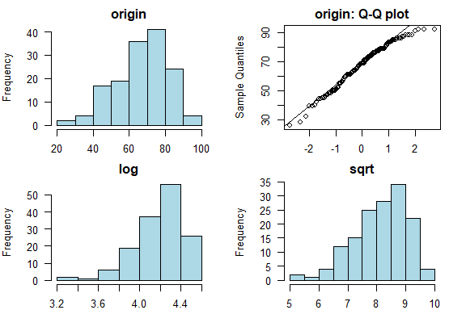

**[ MortalityRate ]**

normality test : Shapiro-Wilk normality test

```
 statistic : 0.65109,  p-value : 3.45793E-17
```

skewness and kurtosis

| type | skewness | kurtosis |
| --- | --- | --- |
| original | 2.9042211 | 12.459474 |
| log transformation | -0.8370724 | 4.683749 |
| sqrt transformation | 1.3190320 | 5.245833 |

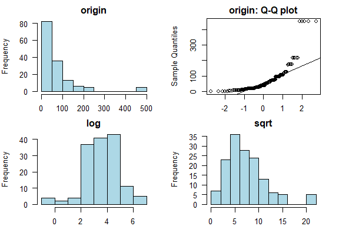

# 3 Relationship Between Variables

## 3.1 Correlation Coefficient

### 3.1.1 Correlation Coefficient by Variable Combination

Table of correlation coefficients (0.5 or more)

| Variable1 | Variable2 | Correlation Coefficient |
| --- | --- | --- |
| MortalityRate | AgeDiagnosed | 0.6142634 |

### 3.1.2 Correlation Plot of Numerical Variables

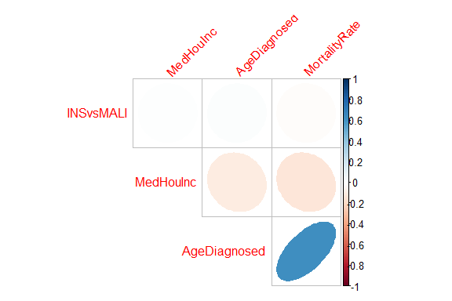

# 4 Target based Analysis

## 4.1 Grouped Descriptive Statistics

### 4.1.1 Grouped Numerical Variables

There is no target variable.

### 4.1.2 Grouped Categorical Variables

There is no target variable.

## 4.2 Grouped Relationship Between Variables

### 4.2.1 Grouped Correlation Coefficient

```
There is no target variable.
```

### 4.2.2 Grouped Correlation Plot of Numerical Variables

```
There is no target variable.
```